# **Introduction to Experimental Design**

### **RCBD**

Now that we’ve analyzed a simple CRD experiment, we can move on to a more complex RCBD experiment. In this example, we have *four treatments* A, B, C, and D arranged in *four blocks*, with *four replicates* each. The response variable is *yield* in bushels/acre (bu/ac), and we want to know if yield is impacted by treatment type or by block.

```r
# Create the data
yld_data <- data.frame(
         trt = rep(c("A", "B", "C", "D"),4),
         blk = as.factor(rep(1:4,each = 4)),
         yld = c(95.3, 114.6, 112.0, 116.6,
                 99.5, 119.1, 115.5, 113.2,
                 98.0, 118.9, 118.2, 117.0,
                 98.0, 118.2, 105.1, 117.8))
yld_data
```

```
##    trt blk   yld
## 1    A   1  95.3
## 2    B   1 114.6
## 3    C   1 112.0
## 4    D   1 116.6
## 5    A   2  99.5
## 6    B   2 119.1
## 7    C   2 115.5
## 8    D   2 113.2
## 9    A   3  98.0
## 10   B   3 118.9
## 11   C   3 118.2
## 12   D   3 117.0
## 13   A   4  98.0
## 14   B   4 118.2
## 15   C   4 105.1
## 16   D   4 117.8
```

First, we will revisit our assumptions. The response variable, yield, is quantitative. We also can assume that our samples, the plots in which we get yield, are independent. Now we can visualize the distribution of yield values and run the Shapiro-Wilk test to see if the data are distributed normally.

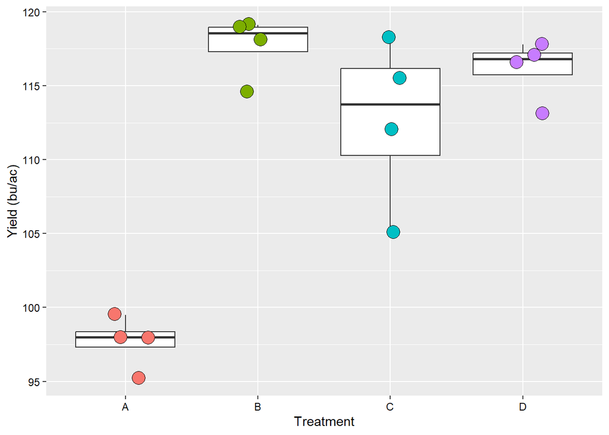

```r
# Visualize the data
ggplot(yld_data, aes(x=trt, y = yld))+
   geom_boxplot(outlier.alpha = 0)+
   geom_jitter(aes(fill = trt), width = 0.2, shape = 21, size = 5,  show.legend = FALSE)+
   labs(y = "Yield (bu/ac)", x = "Treatment")+
   theme(axis.text = element_text(color = "black"))
```

```r
# Shapiro-Wilk test
yld_lm <- lm(yld ~ trt, data = yld_data)
shapiro.test(yld_lm$residuals)
```

```
##
##  Shapiro-Wilk normality test
##
## data:  yld_lm$residuals
## W = 0.91854, p-value = 0.1598
```

The p-value provided by the Shapiro-Wilk test is greater than 0.05, indicating that yield values are normally distributed. Now we can check that variance within treatments is relatively equal.

```r
bartlett.test(yld ~ trt, data = yld_data)
```

```
##
##  Bartlett test of homogeneity of variances
##
## data:  yld by trt
## Bartlett's K-squared = 5.4692, df = 3, p-value = 0.1405
```

The Bartlett test indicates that variance is not significantly different within treatments (p-value > 0.05). We can go ahead with our analysis. We will quickly run a regression model and ANOVA, including block as a variable.

```r
# Regression
RCBD_yld_lm <- lm(yld ~ trt + blk, data = yld_data)
summary(RCBD_yld_lm)
```

```
##
## Call:
## lm(formula = yld ~ trt + blk, data = yld_data)
##
## Residuals:
##     Min      1Q  Median      3Q     Max
## -6.3125 -1.2500  0.6875  1.8125  3.5375
##
## Coefficients:
##             Estimate Std. Error t value Pr(>|t|)
## (Intercept)   96.263      2.188  43.991 8.10e-12 ***
## trtB          20.000      2.339   8.550 1.30e-05 ***
## trtC          15.000      2.339   6.412 0.000123 ***
## trtD          18.450      2.339   7.887 2.48e-05 ***
## blk2           2.200      2.339   0.940 0.371542
## blk3           3.400      2.339   1.453 0.180069
## blk4           0.150      2.339   0.064 0.950275
## ---
## Signif. codes:  0 '***' 0.001 '**' 0.01 '*' 0.05 '.' 0.1 ' ' 1
##
## Residual standard error: 3.308 on 9 degrees of freedom
## Multiple R-squared:  0.9133, Adjusted R-squared:  0.8555
## F-statistic:  15.8 on 6 and 9 DF,  p-value: 0.000257
```

```r
# ANOVA
anova(RCBD_yld_lm)
```

```
## Analysis of Variance Table
##
## Response: yld
##           Df  Sum Sq Mean Sq F value   Pr(>F)
## trt        3 1004.71  334.90 30.5995 4.73e-05 ***
## blk        3   32.63   10.88  0.9937   0.4388
## Residuals  9   98.50   10.94
## ---
## Signif. codes:  0 '***' 0.001 '**' 0.01 '*' 0.05 '.' 0.1 ' ' 1
```

In the ANOVA, the Pr(>F) value (essentially a p-value) indicates that yield values are significantly different by treatment, but not by block. This agrees with the results found in the regression.

#### **Mean comparisons**

We can add several other statistical tests to our toolkit. We can compare the means of different treatment groups with several new tests to see if there is a significant difference between them. These tests include the Least Significant Difference (LSD) test, the Tukey (or Honestly Significant Difference (HSD)) test, and the Duncan test.

There are several packages in R that have functions for means comparison, but we’ll use options in the `agricolae` package. In each case, we will set `alpha = 0.05` to represent our threshold p-value.

```r
# Least Significant Difference (LSD)
RCBD_yld_LSD <- LSD.test(RCBD_yld_lm, trt="trt", alpha=0.05)
RCBD_yld_LSD
```

```
## $statistics
##    MSerror Df     Mean       CV  t.value      LSD
##   10.94472  9 111.0625 2.978756 2.262157 5.291882
##
## $parameters
##         test p.ajusted name.t ntr alpha
##   Fisher-LSD      none    trt   4  0.05
##
## $means
##      yld      std r      se       LCL      UCL   Min   Max     Q25    Q50
## A  97.70 1.749286 4 1.65414  93.95807 101.4419  95.3  99.5  97.325  98.00
## B 117.70 2.102380 4 1.65414 113.95807 121.4419 114.6 119.1 117.300 118.55
## C 112.70 5.666863 4 1.65414 108.95807 116.4419 105.1 118.2 110.275 113.75
## D 116.15 2.028957 4 1.65414 112.40807 119.8919 113.2 117.8 115.750 116.80
##       Q75
## A  98.375
## B 118.950
## C 116.175
## D 117.200
##
## $comparison
## NULL
##
## $groups
##      yld groups
## B 117.70      a
## D 116.15      a
## C 112.70      a
## A  97.70      b
##
## attr(,"class")
## [1] "group"
```

```r
# Tukey/Honestly Significant Difference (HSD)
RCBD_yld_HSD <- HSD.test(RCBD_yld_lm, trt="trt", alpha=0.05)
RCBD_yld_HSD
```

```
## $statistics
##    MSerror Df     Mean       CV      MSD
##   10.94472  9 111.0625 2.978756 7.302848
##
## $parameters
##    test name.t ntr StudentizedRange alpha
##   Tukey    trt   4          4.41489  0.05
##
## $means
##      yld      std r      se   Min   Max     Q25    Q50     Q75
## A  97.70 1.749286 4 1.65414  95.3  99.5  97.325  98.00  98.375
## B 117.70 2.102380 4 1.65414 114.6 119.1 117.300 118.55 118.950
## C 112.70 5.666863 4 1.65414 105.1 118.2 110.275 113.75 116.175
## D 116.15 2.028957 4 1.65414 113.2 117.8 115.750 116.80 117.200
##
## $comparison
## NULL
##
## $groups
##      yld groups
## B 117.70      a
## D 116.15      a
## C 112.70      a
## A  97.70      b
##
## attr(,"class")
## [1] "group"
```

```r
# Duncan test
RCBD_yld_DUN <- duncan.test(RCBD_yld_lm, trt="trt", alpha=0.05)
RCBD_yld_DUN
```

```
## $statistics
##    MSerror Df     Mean       CV
##   10.94472  9 111.0625 2.978756
##
## $parameters
##     test name.t ntr alpha
##   Duncan    trt   4  0.05
##
## $duncan
##      Table CriticalRange
## 2 3.199173      5.291882
## 3 3.339138      5.523403
## 4 3.419765      5.656771
##
## $means
##      yld      std r      se   Min   Max     Q25    Q50     Q75
## A  97.70 1.749286 4 1.65414  95.3  99.5  97.325  98.00  98.375
## B 117.70 2.102380 4 1.65414 114.6 119.1 117.300 118.55 118.950
## C 112.70 5.666863 4 1.65414 105.1 118.2 110.275 113.75 116.175
## D 116.15 2.028957 4 1.65414 113.2 117.8 115.750 116.80 117.200
##
## $comparison
## NULL
##
## $groups
##      yld groups
## B 117.70      a
## D 116.15      a
## C 112.70      a
## A  97.70      b
##
## attr(,"class")
## [1] "group"
```

The important part of the results is in the `$groups` section. Treatment name, yield, and a group identifier are presented. The group identified, a letter, indicates groups where the means are not significantly different. In this case, treatments B, C, and D are in group a, meaning that they are not significantly different. Treatment A is in a different group, showing that its yield data *is* significantly different.

### **RCBD factorial**

Now we will analyze the variation between experimental units in an example multi-factorial RCBD experiment. In this example experiment, our two variables are *treatments A, B, C, and D* and *varieties R and S*. Each combination of A, B, C, D and R and S has *four replicates* that are arranged in *four blocks*. *Yield data* is collected for each experimental unit.

```r
# We create the example data 'data_yld_fac':
data_yld_fac <- data.frame(
         trt = rep(c("A", "A", "B", "B", "C", "C", "D", "D"),4),
         var = rep(c("R", "S"),16),
         blk = as.factor(rep(1:4,each = 8)),
         yld = c(86.6, 92.3, 104.9, 111.6, 105.2, 122, 105.4, 116.6, 81.1, 99.5, 99,
                 119.1, 108.4, 115.5, 94.6, 113.2, 84.8, 98, 107.1, 118.9, 110.8, 118.2,
                 104.1, 117, 84.5, 98, 101.4, 118.2, 109.8, 105.1, 106.1, 117.8))

# Create column 'combo' to describe each combination of the two treatments
data_yld_fac$combo <- paste(data_yld_fac$trt, data_yld_fac$var, sep = "")

data_yld_fac
```

```
##    trt var blk   yld combo
## 1    A   R   1  86.6    AR
## 2    A   S   1  92.3    AS
## 3    B   R   1 104.9    BR
## 4    B   S   1 111.6    BS
## 5    C   R   1 105.2    CR
## 6    C   S   1 122.0    CS
## 7    D   R   1 105.4    DR
## 8    D   S   1 116.6    DS
## 9    A   R   2  81.1    AR
## 10   A   S   2  99.5    AS
## 11   B   R   2  99.0    BR
## 12   B   S   2 119.1    BS
## 13   C   R   2 108.4    CR
## 14   C   S   2 115.5    CS
```

[output cut: 18 more lines]

First we will check the the assumptions we make when applying statistical tests. Our respons variable, yield, is quantitative and we can assume the samples are independent. Now we check to see if the data is normally distributed with the Shapiro-Wilk test.

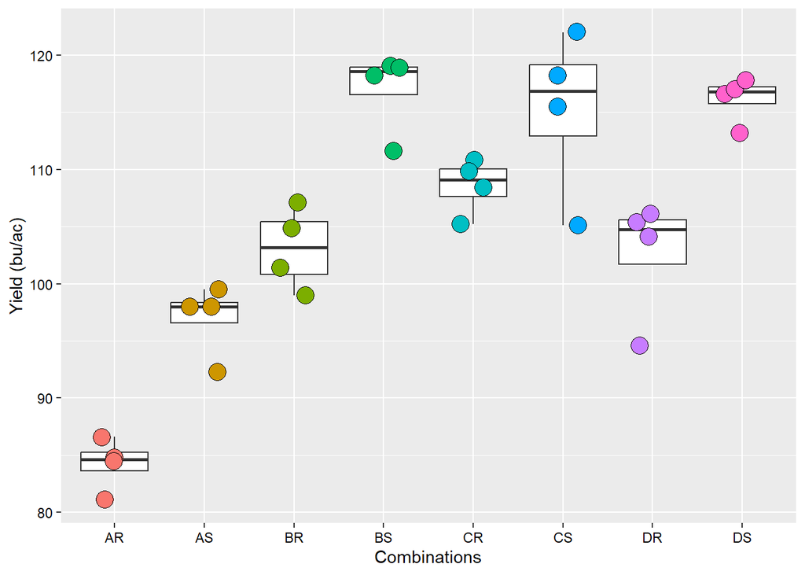

```r
# Let's visualize the distribution of yield ('yld')
ggplot(data_yld_fac, aes(x=combo, y = yld)) +
  geom_boxplot(outlier.alpha = 0) +
  geom_jitter(aes(fill=combo), width = 0.2, shape = 21, size = 5, show.legend = FALSE) +
  labs(y = "Yield (bu/ac)", x = "Combinations") +
  theme(axis.text = element_text(color = "black"))
```

```r
# Apply the Shapiro- Wilk test to the response variable
shapiro.test(data_yld_fac$yld)
```

```
##
##  Shapiro-Wilk normality test
##
## data:  data_yld_fac$yld
## W = 0.94141, p-value = 0.08208
```

The resulting p-value is above the threshold of 0.05, meaning that we can consider the yield values to be normally distributed. Now we can use the Bartlett test to see if variance levels among different treatments are relatively equal.

```r
# Apply the Bartlett test
bartlett.test(yld ~ combo, data = data_yld_fac)
```

```
##
##  Bartlett test of homogeneity of variances
##
## data:  yld by combo
## Bartlett's K-squared = 7.5892, df = 7, p-value = 0.3702
```

The p-value of 0.3702 indicates that treatments have similar levels of variance between samples. We can move forward with our analysis by applying a linear model and running an ANOVA to the data. This will be similar to the first example, a CRD experiment, but instead of one explanatory variable, we’ll have two. We can also include block number in the model to see if there was significant variation across the different blocks.

```r
# Create linear model
RCBD_yld_lm <- lm(yld ~ trt + var + blk, data = data_yld_fac)
summary(RCBD_yld_lm)
```

```
##
## Call:
## lm(formula = yld ~ trt + var + blk, data = data_yld_fac)
##
## Residuals:
##      Min       1Q   Median       3Q      Max
## -12.2750  -1.5313   0.3563   2.7250   4.8875
##
## Coefficients:
##             Estimate Std. Error t value Pr(>|t|)
## (Intercept)  84.8625     2.0791  40.817  < 2e-16 ***
## trtB         19.4250     2.0791   9.343 1.82e-09 ***
## trtC         21.2750     2.0791  10.233 3.13e-10 ***
## trtD         18.7500     2.0791   9.018 3.55e-09 ***
## varS         11.7000     1.4702   7.958 3.46e-08 ***
## blk2         -1.7750     2.0791  -0.854    0.402
## blk3          1.7875     2.0791   0.860    0.398
## blk4         -0.4625     2.0791  -0.222    0.826
## ---
## Signif. codes:  0 '***' 0.001 '**' 0.01 '*' 0.05 '.' 0.1 ' ' 1
##
## Residual standard error: 4.158 on 24 degrees of freedom
## Multiple R-squared:  0.8948, Adjusted R-squared:  0.8642
## F-statistic: 29.17 on 7 and 24 DF,  p-value: 2.985e-10
```

The output of the regression model is more complex than in our previous example. Instead of the adjusted R-squared and p-value referring to a single explanatory variable, they indicate the fit of the *overall model*. In this case, 86.42% of variation can be attributed to treatment, variety, and block. The p-value is very small, so we can be quite sure that we do not have a falsely positive result.

Now look at the values under ‘Estimate’. The values for treatments B, C, and D and variety S are quite large, with relatively small p-values. In contrast, block number has much smaller estimated values and non-significant p-values (p>0.05). We can conclude that treatment and variety type significantly influence yield, while block does not.

```r
# ANOVA
anova(RCBD_yld_lm)
```

```
## Analysis of Variance Table
##
## Response: yld
##           Df  Sum Sq Mean Sq F value    Pr(>F)
## trt        3 2383.55  794.52 45.9503 4.231e-10 ***
## var        1 1095.12 1095.12 63.3357 3.461e-08 ***
## blk        3   52.07   17.36  1.0039    0.4082
## Residuals 24  414.98   17.29
## ---
## Signif. codes:  0 '***' 0.001 '**' 0.01 '*' 0.05 '.' 0.1 ' ' 1
```

In the ANOVA report, we can see that the F-value for both treatment and variety are large with small (<0.05) p-values, indicating that treatment and variety are significant in determining yield. In contrast, block has a small F-value and large p-value, showing that yield is not significantly impacted by block. This agrees with the results shown in the regression.